# Coursework Report

*N* removed NAs: 2

*N* removed typo: 1

*N* removed <18: 21

*N* total clean: 126

| Group | *N* | *M*<sub>age</sub> | *M*<sub>rating</sub> |
| --- | --- | --- | --- |
| Control | 63 | 20.6 | 6.11 |
| Experim | 63 | 20.8 | 7.02 |

**Main analysis results**

*t*(124) = -6.16, *p* < .001

[interactive chart not shown]

[figure not shown]

[interactive chart not shown]

# Coursework Report

Analysing Data, Spring 2020

# Methods

## Participants

For this current replication study, initially, 150 participants were recruited. However, 21 participants were removed from the final data, due to ethical reasons since they were under the age of 18 years old. In addition, 3 participants were excluded from the study, because they failed to provide the correct information regarding their age, which was necessary in order to proceed with the experiment. Ultimately, the remaining 126 participants (*M*<sub>age</sub> = 20.71, *SD*<sub>age</sub> = 1.74, range = 18 - 26) , whose data were used in the final study and are displayed in Table 1.“Descriptive Statistics for Age of Participants”, were randomly divided into two groups, the experimental and control condition.

Table 1.Descriptive Statistics for Age of Participants

| Mean Age | Standard Deviation | Minimum Age | Maximum Age | Range |
| --- | --- | --- | --- | --- |
| 20.7 | 1.74 | 18 | 26 | 8 |

## Results

The replication study investigated whether participants would rate differently the attractiveness of a man shown in an image, depending on the colour frame surrounding him. In order to test that, the data provided by the participants were converted into a computer program named “RStudio”, which was responsible for interpreting the information. Furthermore, the mean responses of each condition group to the three questions, regarding the attractiveness of the man, were calculated, thus providing the composite scores. By using an independent-measures two-tailed t-test, the results indicated that there was a significant difference in the mean attractiveness rating of the red in opposition to the white colour group  
(*M*<sub>diff</sub> = -0.91 , 95% CI [-1.2,-0.62]) (*t* (124) = -6.16, p < 0.001. Specifically, this implies that the experimental group rated considerably higher (M=7.01) the attractiveness of the man in the red colored frame, in contrast with the control group (M=6.10) who viewed the white frame, as also confirmed by Table 2. “Descriptives of Results by Condition” and as illustrated in the presented plot. Therefore, it is highly unlikely that these results derive from the same population, meaning that the null hypothesis is rejected, since colour has had an impact on the participants responses regarding attractiveness.

Table 2. Descriptives of Results by Condition

| Condition | Mean Score | Standard Deviation | Minimum Score | Maximum Score | Range |
| --- | --- | --- | --- | --- | --- |
| control | 6.11 | 0.78 | 4.67 | 8.00 | 3.33 |
| experimental | 7.02 | 0.88 | 4.00 | 8.33 | 4.33 |

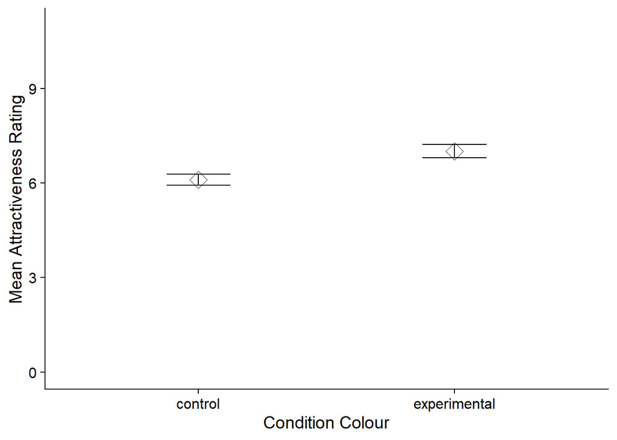

# Discussion

The experiment explored whether red colour would affect the perception of a man’s attractiveness, by conducting a replication of the original study, directed by Elliot et al. (2010). The results of this experiment supported the hypothesis suggesting that red colour has an impact on individual’s perception of attractiveness, as the original study (Elliot et al., 2010) predicted. The participants’ responses to the three questions presented, regarding the attractiveness of the man portrayed in a picture, indicated that red colour effected their assessment, since the mean responses of the experimental group were significantly higher than the one’s of the control group. Even though the findings of the current study correspond with the results of the original, further investigation is needed in order to determine if red colour can affect one’s perceived attractiveness.  
The current replication study presents various strengths, since there is great indication supporting the conjunction between red and attraction (Eliot et al., 2010). Moreover, red has been linked with strength and power, thus closely associated with physical and sexual attraction (Litte & Hill, 2007), while a correlation between red and attractiveness has also been observed in female birds (Waitt et al., 2003). However, recent replication studies have found no significant relationship between attractiveness and the colour red, thus contradicting the findings of the current study. Specifically, a study conducted by Peperkoorn et al. (2016), examined whether a woman in a red background would be rated by men as the most attractive, compared to the same woman in a white or black frame. The results did not support the initial hypothesis, meaning that there was no difference in attractiveness ratings between the woman viewed in the red frame in opposition with the one in a black or white background. In addition, a “close replication” experiment run by Goldbach et al. (2015), in which participants viewed a photo of the target person on either a red or a white background, retained the null hypothesis, meaning that no association was found between an individual’s perception of attractiveness and the colour red. Therefore, the current replication study has presented some limitations, which need to be taken into consideration, in order to aid future research in succeeding more accurate and concrete results.  
Primarily, the present replication study presented only an individual image, which, specifically, included a Caucasian man, meaning that we are unable to predict the results in case different men who varied in skin colour were displayed to the participants. In order to avoid any type of cultural or racial biases and ensure that the findings can be generalized to a broader population, future studies could show a large set of images portraying targets of diverse races and backgrounds, as the model developed by Young et al. (2015) suggested. Moreover, the findings reported are relative effects of red compared to white color, and even though the results indicated that red had a significant impact on the perception of attractiveness, we are incapable of predicting if the same results would occur in case red was contrasted with several different colors, such as blue (Elliot & Niesta, 2008) or green (Pazda et al., 2012). Future research may use multiple colors as the independent variable, in order to determine whether the manipulation of attractiveness presents the same results, in the occasion that red is compared with various, vivid colors. Finally, another limitation of the study is the design method that was used. In the current replication attempt, a between-subjects design was preferred, meaning that each participant viewed either the man in a red frame or the same man in a white frame, as other numerous studies have used as well (Peperkoorn et al.,2016). Hence, we are unable to forecast if the results would be similar in case all participants viewed and rated each image in which the man was presented with a different colored background, as Roberts et al. (2010) attempted, by using a within-subjects design. Future studies could combine both designs (mixed design), in order to ensure good methodological practice and more accurate results, as Peperkoorn et al.(2016) proposed.  
In conclusion, the current replication study succeeded in finding a correlation between red and the perception of attractiveness, as the original study of Elliot et al. (2010) predicted. The findings supported the initial hypothesis, which argued that color would have an impact on the mean ratings of a man’s attractiveness. The null hypothesis was, therefore, rejected, meaning that there is very little chance the results derived by chance. Even though the study presented some limitations regarding the procedure of the experiment and the design method, its reliability is not doubted. Nonetheless, numerous proposals were made to improve future replication studies, in order to determine the influence that red color has in one’s perception of attractiveness.

# References

Elliot, A., & Maier, M. (2013). The red-attractiveness effect, applying the Ioannidis and Trikalinos (2007b) test, and the broader scientific context: A reply to Francis (2013). Journal Of Experimental Psychology: General, 142(1), 297-300. https://doi.org/10.1037/a0029592

Elliot, A., Niesta Kayser, D., Greitemeyer, T., Lichtenfeld, S., Gramzow, R., Maier, M., & Liu, H. (2010). Red, rank, and romance in women viewing men. Journal Of Experimental Psychology: General, 139(3), 399-417. https://doi.org/10.1037/a0019689

Francis, G. (2013). Publication bias in “Red, rank, and romance in women viewing men,” by Elliot et al. (2010). Journal Of Experimental Psychology: General, 142(1), 292-296. https://doi.org/10.1037/a0027923

Grahe, J., Reifman, A., Hermann, A., Walker, M., Oleson, K., Nario-Redmond, M., & Wiebe, R. (2012). Harnessing the Undiscovered Resource of Student Research Projects. Perspectives On Psychological Science, 7(6), 605-607. https://doi.org/10.1177/1745691612459057

Hesslinger, V., Goldbach, L., & Carbon, C. (2015). Men in red: A reexamination of the red-attractiveness effect. Psychonomic Bulletin & Review, 22(4), 1142-1148. https://doi.org/10.3758/s13423-015-0866-8

Peperkoorn, L., Roberts, S., & Pollet, T. (2016). Revisiting the Red Effect on Attractiveness and Sexual Receptivity. Evolutionary Psychology, 14(4), 147470491667384. https://doi.org/10.1177/1474704916673841

Williams, L., Schofield, T., & Whitford, T. (2017). Romantic Red: Testing the Characteristics of Color–Attraction Effects in a Novel Paradigm. Collabra: Psychology, 3(1), 10. https://doi.org/10.1525/collabra.54

Young, S. (2015). The effect of red on male perceptions of female attractiveness: Moderation by baseline attractiveness of female faces. European Journal Of Social  
Psychology, 45(2), 146-151. https://doi.org/10.1002/ejsp.2098